# Lab 2 - Distributed Denial of Service Attacks

Hailey Werth and Myles Cagle

2/27/2020

# Question B

## Reading in the data and selecting variables that we believed would have explanatory power

```r
pacman::p_load(tidyverse, magrittr, jsonlite, igraph, robustHD, caret, pROC)

df = read.csv("Portmap.csv", stringsAsFactors = F)

df %<>% select(c(Source.IP, Destination.IP, Total.Fwd.Packets, Total.Backward.Packets,
                Fwd.IAT.Total, Bwd.IAT.Total, Fwd.PSH.Flags,
                 Bwd.Header.Length, Fwd.Packets.s,
                 Bwd.Packets.s, Min.Packet.Length, Max.Packet.Length, Average.Packet.Size, Active.Mean, Idle.Mean, SimillarHTTP,
                 Inbound, Label))

str(df)
```

```
## 'data.frame':    191694 obs. of  18 variables:
##  $ Source.IP             : chr  "192.168.50.254" "192.168.50.253" "192.168.50.6" "192.168.50.6" ...
##  $ Destination.IP        : chr  "224.0.0.5" "224.0.0.5" "172.217.10.98" "172.217.7.2" ...
##  $ Total.Fwd.Packets     : int  45 56 6 6 6 2 2 2 5 40 ...
##  $ Total.Backward.Packets: int  0 0 2 2 2 0 0 0 0 40 ...
##  $ Fwd.IAT.Total         : num  1.14e+08 1.14e+08 3.64e+07 3.64e+07 3.64e+07 ...
##  $ Bwd.IAT.Total         : num  0 0 2 2 2 ...
##  $ Fwd.PSH.Flags         : int  0 0 1 1 1 0 0 0 0 0 ...
##  $ Bwd.Header.Length     : int  0 0 40 40 40 0 0 0 0 0 ...
##  $ Fwd.Packets.s         : num  0.393 0.49 0.165 0.165 0.165 ...
##  $ Bwd.Packets.s         : num  0 0 0.0549 0.0549 0.0549 ...
##  $ Min.Packet.Length     : num  0 0 6 6 6 6 6 6 300 0 ...
##  $ Max.Packet.Length     : num  0 0 46 46 46 6 6 6 300 0 ...
##  $ Average.Packet.Size   : num  0 0 31.8 31.8 31.8 ...
##  $ Active.Mean           : num  8186 35028 62416 62413 62409 ...
##  $ Idle.Mean             : num  9529897 9493930 36373056 36372291 36372216 ...
##  $ SimillarHTTP          : chr  "0" "0" "0" "0" ...
##  $ Inbound               : int  0 0 0 0 0 0 1 0 0 1 ...
##  $ Label                 : chr  "BENIGN" "BENIGN" "BENIGN" "BENIGN" ...
```

```r
summary(df)
```

```
##   Source.IP         Destination.IP     Total.Fwd.Packets
##  Length:191694      Length:191694      Min.   :    1.00
##  Class :character   Class :character   1st Qu.:    2.00
##  Mode  :character   Mode  :character   Median :    2.00
##                                        Mean   :    2.27
##                                        3rd Qu.:    2.00
##                                        Max.   :20444.00
##  Total.Backward.Packets Fwd.IAT.Total       Bwd.IAT.Total
##  Min.   :    0.00       Min.   :        0   Min.   :        0
##  1st Qu.:    0.00       1st Qu.:        1   1st Qu.:        0
##  Median :    0.00       Median :        1   Median :        0
##  Mean   :    0.38       Mean   :   334807   Mean   :   283045
##  3rd Qu.:    0.00       3rd Qu.:        1   3rd Qu.:        0
##  Max.   :31700.00       Max.   :119947247   Max.   :119947264
##  Fwd.PSH.Flags      Bwd.Header.Length  Fwd.Packets.s     Bwd.Packets.s
##  Min.   :0.000000   Min.   :     0.0   Min.   :      0   Min.   :      0.0
##  1st Qu.:0.000000   1st Qu.:     0.0   1st Qu.:1000000   1st Qu.:      0.0
##  Median :0.000000   Median :     0.0   Median :2000000   Median :      0.0
##  Mean   :0.003579   Mean   :     8.3   Mean   :1545580   Mean   :    132.4
##  3rd Qu.:0.000000   3rd Qu.:     0.0   3rd Qu.:2000000   3rd Qu.:      0.0
##  Max.   :1.000000   Max.   :634024.0   Max.   :3000000   Max.   :1000000.0
##  Min.Packet.Length Max.Packet.Length Average.Packet.Size  Active.Mean
##  Min.   :   0.0    Min.   :   0.0    Min.   :   0.0      Min.   :       0
##  1st Qu.: 229.0    1st Qu.: 229.0    1st Qu.: 343.5      1st Qu.:       0
##  Median : 229.0    Median : 229.0    Median : 343.5      Median :       0
##  Mean   : 224.6    Mean   : 232.6    Mean   : 338.3      Mean   :    3126
##  3rd Qu.: 229.0    3rd Qu.: 229.0    3rd Qu.: 343.5      3rd Qu.:       0
##  Max.   :1000.0    Max.   :3583.0    Max.   :1500.0      Max.   :14006532
##    Idle.Mean        SimillarHTTP          Inbound          Label
##  Min.   :       0   Length:191694      Min.   :0.0000   Length:191694
##  1st Qu.:       0   Class :character   1st Qu.:1.0000   Class :character
##  Median :       0   Mode  :character   Median :1.0000   Mode  :character
##  Mean   :  117858                      Mean   :0.9771
##  3rd Qu.:       0                      3rd Qu.:1.0000
##  Max.   :82791800                      Max.   :1.0000
```

```r
df = select(df,-SimillarHTTP)
df = select(df,-Source.IP)
df = select(df,-Destination.IP)
```

Started with 24 variables, ended with 15 for analysis. Dropped based on near-zero variance, low predictive power and negative values.Decided to drop IP variables rather than group them into a factor because there are a number of points in the data where the IP addresses do not match up to a location. Most likely because they are private. Also, converting them to numeric did not make much sense to us in regard to our own model.

## Changing Variables to Factors

```r
df$Inbound = as.factor(df$Inbound)
df$Fwd.PSH.Flags = as.factor(df$Fwd.PSH.Flags)
df$Label = recode_factor(df$Label, "1"="Portmap", "0"="Benign")
```

## Visualizing the data to better understand our dataset

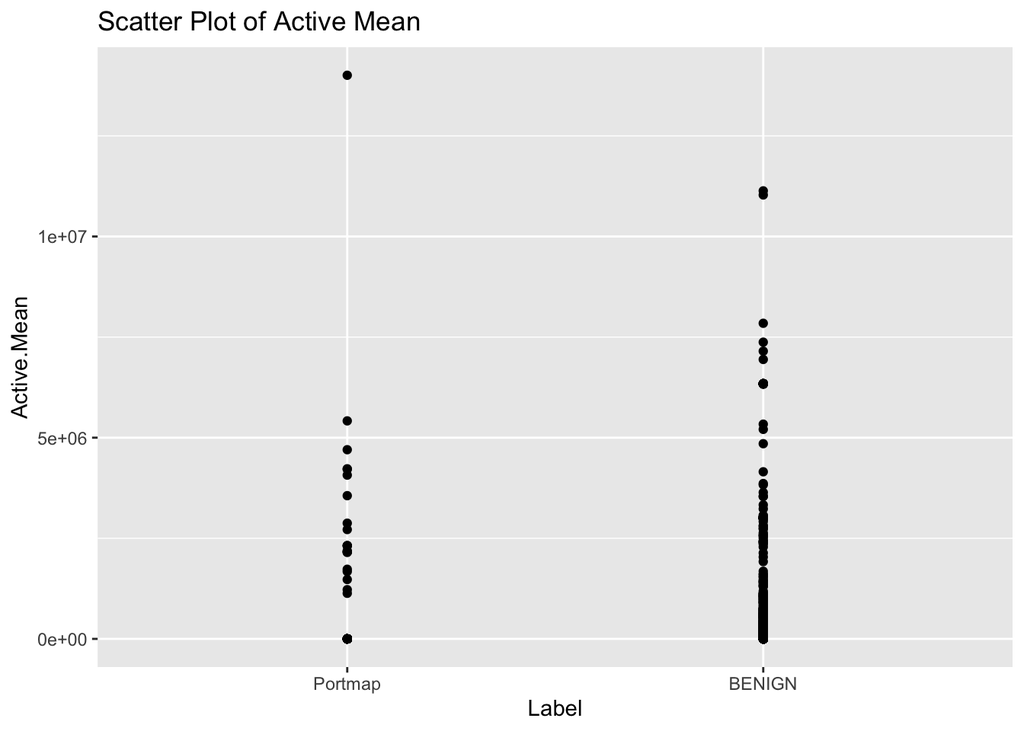

```r
ggplot(df,aes(x=Label, y=Active.Mean)) + geom_point()+ggtitle("Scatter Plot of Active Mean")
```

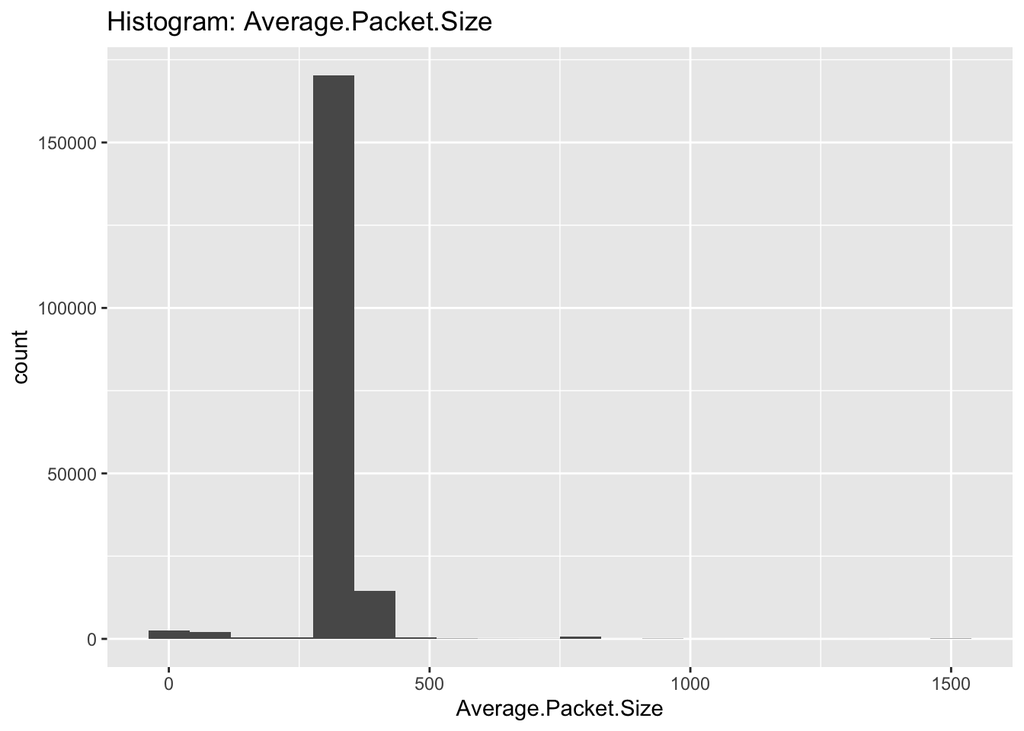

```r
ggplot(df,aes(x=Average.Packet.Size)) + geom_histogram(bins=20) + ggtitle("Histogram: Average.Packet.Size")
```

```r
df_grouped1 = df %>% group_by(Label) %>% select_if(is.numeric) %>% summarise_all(list(avg = mean, stdDev = sd)) %>% data.frame()

df_grouped1
```

```
##     Label Total.Fwd.Packets_avg Total.Backward.Packets_avg Fwd.IAT.Total_avg
## 1 Portmap               2.01741                 0.01945336          18221.92
## 2  BENIGN              12.24018                14.67955218       12837723.82
##   Bwd.IAT.Total_avg Bwd.Header.Length_avg Fwd.Packets.s_avg Bwd.Packets.s_avg
## 1          14665.01             0.3266795         1579666.6          30.77809
## 2       10882163.50           323.0494297          199388.8        4145.29501
##   Min.Packet.Length_avg Max.Packet.Length_avg Average.Packet.Size_avg
## 1             229.80728              230.0091               344.68427
## 2              18.38509              333.8764                86.70152
##   Active.Mean_avg Idle.Mean_avg Total.Fwd.Packets_stdDev
## 1        367.1088      3561.798                 1.170078
## 2     112076.5627   4631777.907               297.654179
##   Total.Backward.Packets_stdDev Fwd.IAT.Total_stdDev Bwd.IAT.Total_stdDev
## 1                        1.2149              1307662              1231812
## 2                      461.3946             34707579             32214317
##   Bwd.Header.Length_stdDev Fwd.Packets.s_stdDev Bwd.Packets.s_stdDev
## 1                 15.88571             763590.2              1146.07
## 2               9235.88434             537276.3             46331.27
##   Min.Packet.Length_stdDev Max.Packet.Length_stdDev Average.Packet.Size_stdDev
## 1                 30.94562                 32.49035                   46.32944
## 2                 24.08064                742.94125                  149.63559
##   Active.Mean_stdDev Idle.Mean_stdDev
## 1           44709.97         417667.2
## 2          648721.32       14226827.8
```

## Scaling the numeric variables

```r
df2 = df %>% select_if(is.numeric) %>% scale() %>% data.frame()
```

```r
# Adding categorical variables back into the dataframe

df2['Inbound']= df['Inbound']
df2['Fwd.PSH.Flags']= df['Fwd.PSH.Flags']
df2['Label']= df['Label']
```

## Partitioning the Data

```r
trainRowNums = sample(1:nrow(df2), round(0.7*nrow(df2)))

trainData = df[trainRowNums,]
testData = df[-trainRowNums,]
```

## Model Building and Validation

```r
options(scipen = 999)
MODEL1 <- glm(Label ~., data = trainData, family ='binomial')
summary(MODEL1)
```

```
##
## Call:
## glm(formula = Label ~ ., family = "binomial", data = trainData)
##
## Deviance Residuals:
##     Min       1Q   Median       3Q      Max
## -3.7665  -0.0138  -0.0138  -0.0088   4.3842
##
## Coefficients:
##                               Estimate      Std. Error z value
## (Intercept)             5.668307051630  0.183974270751  30.810
## Total.Fwd.Packets      -0.118466569527  0.022124973928  -5.354
## Total.Backward.Packets  0.054055241932  0.013108376733   4.124
## Fwd.IAT.Total           0.000000045814  0.000000013271   3.452
## Bwd.IAT.Total          -0.000000056589  0.000000012611  -4.487
## Fwd.PSH.Flags1          3.108509142324  0.781635337542   3.977
## Bwd.Header.Length       0.001115512833  0.000513311173   2.173
## Fwd.Packets.s           0.000000892619  0.000000185205   4.820
## Bwd.Packets.s           0.000005790237  0.000004278279   1.353
## Min.Packet.Length      -0.048673557630  0.002923323976 -16.650
## Max.Packet.Length       0.000149275680  0.000386881660   0.386
## Average.Packet.Size    -0.000380111310  0.001714896710  -0.222
## Active.Mean             0.000001217308  0.000000214917   5.664
## Idle.Mean               0.000000008277  0.000000015316   0.540
## Inbound1               -5.230664506499  0.201097852150 -26.011
##                                    Pr(>|z|)
## (Intercept)            < 0.0000000000000002 ***
## Total.Fwd.Packets              0.0000000858 ***
## Total.Backward.Packets         0.0000372806 ***
## Fwd.IAT.Total                      0.000556 ***
## Bwd.IAT.Total                  0.0000072178 ***
## Fwd.PSH.Flags1                 0.0000698107 ***
## Bwd.Header.Length                  0.029767 *
## Fwd.Packets.s                  0.0000014382 ***
## Bwd.Packets.s                      0.175927
## Min.Packet.Length      < 0.0000000000000002 ***
## Max.Packet.Length                  0.699613
## Average.Packet.Size                0.824584
## Active.Mean                    0.0000000148 ***
## Idle.Mean                          0.588910
## Inbound1               < 0.0000000000000002 ***
## ---
## Signif. codes:  0 '***' 0.001 '**' 0.01 '*' 0.05 '.' 0.1 ' ' 1
##
## (Dispersion parameter for binomial family taken to be 1)
##
##     Null deviance: 31112.9  on 134185  degrees of freedom
## Residual deviance:  1803.6  on 134171  degrees of freedom
## AIC: 1833.6
##
## Number of Fisher Scoring iterations: 12
```

```r
#null <-glm(Label~1, data = trainData, family = "binomial")
#full <-glm(Label~Total.Fwd.Packets + Fwd.PSH.Flags + Min.Packet.Length +
#            Inbound + Active.Mean, data = trainData, family = "binomial")
#MODEL2 <-step(null,list(lower =formula(null), upper =formula(full)),data = trainData, direction = "both", trace = 0)
#summary(MODEL2)


MODEL3 = glm(Label~Total.Fwd.Packets + Fwd.PSH.Flags + Active.Mean + Inbound, data = trainData, family = "binomial")
summary(MODEL3)
```

```
##
## Call:
## glm(formula = Label ~ Total.Fwd.Packets + Fwd.PSH.Flags + Active.Mean +
##     Inbound, family = "binomial", data = trainData)
##
## Deviance Residuals:
##    Min      1Q  Median      3Q     Max
## -6.914  -0.088  -0.088  -0.088   3.338
##
## Coefficients:
##                        Estimate    Std. Error z value            Pr(>|z|)
## (Intercept)        1.8782801775  0.0682387085  27.525 <0.0000000000000002 ***
## Total.Fwd.Packets  0.0148637361  0.0063558093   2.339              0.0194 *
## Fwd.PSH.Flags1     7.9053393417  0.4697905053  16.827 <0.0000000000000002 ***
## Active.Mean        0.0000017762  0.0000001504  11.813 <0.0000000000000002 ***
## Inbound1          -7.4605676569  0.0775470122 -96.207 <0.0000000000000002 ***
## ---
## Signif. codes:  0 '***' 0.001 '**' 0.01 '*' 0.05 '.' 0.1 ' ' 1
##
## (Dispersion parameter for binomial family taken to be 1)
##
##     Null deviance: 31112.9  on 134185  degrees of freedom
## Residual deviance:  8568.5  on 134181  degrees of freedom
## AIC: 8578.5
##
## Number of Fisher Scoring iterations: 8
```

```r
p3.train <-predict(MODEL3, data = trainData, type = "response")
p3.valid <-predict(MODEL3, newdata = testData, type = "response")
r3.train <-roc(trainData$Label, p3.train)
r3.valid <-roc(testData$Label, p3.valid)
m3.train.auc <- r3.train$auc
m3.valid.auc <- r3.valid$auc
m3.train.auc
```

```
## Area under the curve: 0.8922
```

```r
m3.valid.auc
```

```
## Area under the curve: 0.904
```

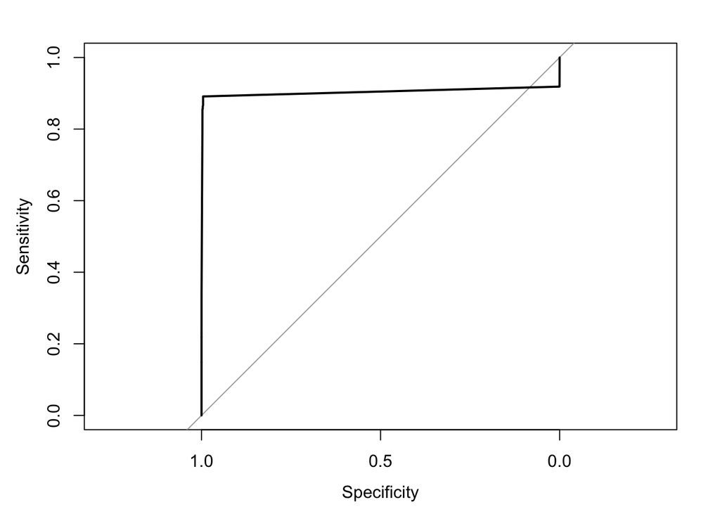

```r
plot(r3.valid)
```

```r
pacman::p_load(devtools)
install_github("ltorgo/DMwR2",ref="master")
```

```
## Skipping install of 'DMwR2' from a github remote, the SHA1 (c19cb087) has not changed since last install.
##   Use `force = TRUE` to force installation
```

```r
#MSSQL Dataset
MSSQLcolnames = read.csv("MSSQL.csv", nrows = 1, header = TRUE)
dfMSSQL = DMwR2::sampleCSV("MSSQL.csv", percORn = 0.15, header = TRUE)
colnames(dfMSSQL) <- colnames(MSSQLcolnames)

dfMSSQL %<>% select(c(Total.Fwd.Packets, Total.Backward.Packets,
                 Fwd.IAT.Total, Bwd.IAT.Total, Fwd.PSH.Flags,
                 Bwd.Header.Length, Fwd.Packets.s,
                 Bwd.Packets.s, Min.Packet.Length, Max.Packet.Length, Average.Packet.Size, Active.Mean, Idle.Mean,
                 Inbound, Label))

summary(dfMSSQL)
```

```
##  Total.Fwd.Packets Total.Backward.Packets Fwd.IAT.Total
##  Min.   :   1.00   Min.   :  0.0000       Min.   :        0
##  1st Qu.:   2.00   1st Qu.:  0.0000       1st Qu.:        1
##  Median :   2.00   Median :  0.0000       Median :        1
##  Mean   :   2.11   Mean   :  0.0054       Mean   :     6307
##  3rd Qu.:   2.00   3rd Qu.:  0.0000       3rd Qu.:        1
##  Max.   :8724.00   Max.   :730.0000       Max.   :118926815
##  Bwd.IAT.Total       Fwd.PSH.Flags       Bwd.Header.Length
##  Min.   :        0   Min.   :0.0000000   Min.   :-4250875720
##  1st Qu.:        0   1st Qu.:0.0000000   1st Qu.:          0
##  Median :        0   Median :0.0000000   Median :          0
##  Mean   :     2212   Mean   :0.0001731   Mean   :     -22079
##  3rd Qu.:        0   3rd Qu.:0.0000000   3rd Qu.:          0
##  Max.   :118849203   Max.   :1.0000000   Max.   :      23376
##  Fwd.Packets.s     Bwd.Packets.s     Min.Packet.Length Max.Packet.Length
##  Min.   :      0   Min.   :      0   Min.   :   0.0    Min.   :   0.0
##  1st Qu.:1000000   1st Qu.:      0   1st Qu.: 434.0    1st Qu.: 434.0
##  Median :2000000   Median :      0   Median : 481.0    Median : 481.0
##  Mean   :1585542   Mean   :      4   Mean   : 562.2    Mean   : 562.4
##  3rd Qu.:2000000   3rd Qu.:      0   3rd Qu.: 591.0    3rd Qu.: 591.0
##  Max.   :4000000   Max.   :1333333   Max.   :1472.0    Max.   :3159.0
##  Average.Packet.Size  Active.Mean        Idle.Mean           Inbound
##  Min.   :   0.0      Min.   :      0   Min.   :       0   Min.   :0.0000
##  1st Qu.: 651.0      1st Qu.:      0   1st Qu.:       0   1st Qu.:1.0000
##  Median : 718.5      Median :      0   Median :       0   Median :1.0000
##  Mean   : 842.9      Mean   :     38   Mean   :    3770   Mean   :0.9993
##  3rd Qu.: 886.5      3rd Qu.:      0   3rd Qu.:       0   3rd Qu.:1.0000
##  Max.   :2208.0      Max.   :6326783   Max.   :63405044   Max.   :1.0000
##     Label
##  Length:866368
##  Class :character
##  Mode  :character
##
##
##
```

```r
#UDPLag Dataset
UDPLagcolnames = read.csv("UDPLag.csv", nrows = 1, header = TRUE)
dfUDPLag = DMwR2::sampleCSV("UDPLag.csv", percORn = 0.25, header = TRUE)
colnames(dfUDPLag) <- colnames(UDPLagcolnames)

dfUDPLag %<>% select(c(Total.Fwd.Packets, Total.Backward.Packets,
                 Fwd.IAT.Total, Bwd.IAT.Total, Fwd.PSH.Flags,
                 Bwd.Header.Length, Fwd.Packets.s,
                 Bwd.Packets.s, Min.Packet.Length, Max.Packet.Length, Average.Packet.Size, Active.Mean, Idle.Mean,
                 Inbound, Label))

summary(dfUDPLag)
```

```
##  Total.Fwd.Packets Total.Backward.Packets Fwd.IAT.Total
##  Min.   :  1.000   Min.   :  0.000        Min.   :        0
##  1st Qu.:  2.000   1st Qu.:  0.000        1st Qu.:        1
##  Median :  2.000   Median :  0.000        Median :        2
##  Mean   :  4.161   Mean   :  1.143        Mean   :  9951424
##  3rd Qu.:  4.000   3rd Qu.:  2.000        3rd Qu.:   109408
##  Max.   :492.000   Max.   :728.000        Max.   :119943744
##  Bwd.IAT.Total       Fwd.PSH.Flags      Bwd.Header.Length  Fwd.Packets.s
##  Min.   :        0   Min.   :0.000000   Min.   :    0.00   Min.   :      0.0
##  1st Qu.:        0   1st Qu.:0.000000   1st Qu.:    0.00   1st Qu.:     25.9
##  Median :        0   Median :0.000000   Median :    0.00   Median :  20000.0
##  Mean   :  3674910   Mean   :0.001958   Mean   :   23.36   Mean   : 667073.6
##  3rd Qu.:        1   3rd Qu.:0.000000   3rd Qu.:   40.00   3rd Qu.:2000000.0
##  Max.   :119943719   Max.   :1.000000   Max.   :23312.00   Max.   :3000000.0
##  Bwd.Packets.s       Min.Packet.Length Max.Packet.Length Average.Packet.Size
##  Min.   :      0.0   Min.   :  0.0     Min.   :   0      Min.   :   0.0
##  1st Qu.:      0.0   1st Qu.:  6.0     1st Qu.:   6      1st Qu.:   7.5
##  Median :      0.0   Median :  6.0     Median :   6      Median :   9.0
##  Mean   :   3767.2   Mean   :116.8     Mean   : 130      Mean   : 164.7
##  3rd Qu.:      0.1   3rd Qu.:330.0     3rd Qu.: 375      3rd Qu.: 432.0
##  Max.   :2000000.0   Max.   :581.0     Max.   :3605      Max.   :1675.5
##   Active.Mean        Idle.Mean           Inbound          Label
##  Min.   :      0   Min.   :       0   Min.   :0.0000   Length:181291
##  1st Qu.:      0   1st Qu.:       0   1st Qu.:1.0000   Class :character
##  Median :      0   Median :       0   Median :1.0000   Mode  :character
##  Mean   :  23408   Mean   : 2661457   Mean   :0.9887
##  3rd Qu.:      0   3rd Qu.:       0   3rd Qu.:1.0000
##  Max.   :9930155   Max.   :94855479   Max.   :1.0000
```

When sampling the data we wanted to make sure we got a solid representation of the entire dataset.

For the MSSQL dataset we decided that 15% of the data seemed like a well rounded choice of not getting too much data but also making sure we have an unbiased set of data given how large this dataset was at nearly 6 million observations.

For the UDPLag dataset we went with a larger percent of 25% because this dataset was much smaller than MSSQL. The reason we went with 25% is because even though it was randomly selected we wanted to have around as much data as we had for the Portmap dataset so that it would be comparable.

Overall, we came to these conclusions after doing research into how much data is generally needed when doing predictive analytics. We found that while obviously more data doesnt hurt, in larger datasets especially for more traditional predictive modeling there is a point of diminishing returns. That is how we came to the conclusion of what a reasonable amount of data would be for this project.

## Visualizing the data for better comparison with Portmap

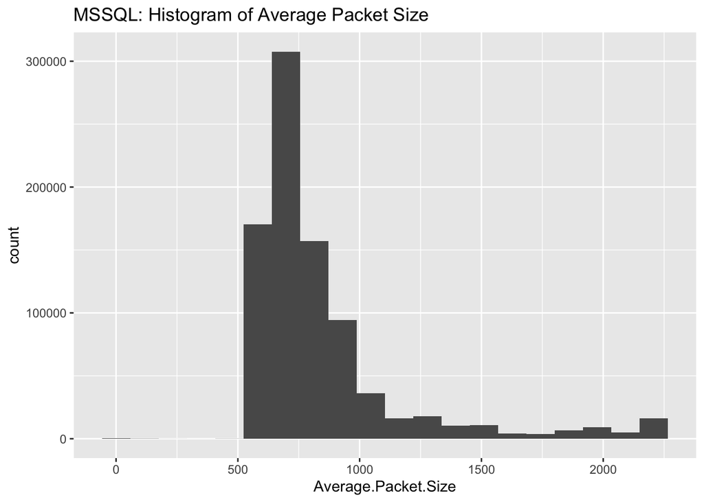

```r
#MSSQL Dataset Visuals
ggplot(dfMSSQL,aes(x=Average.Packet.Size)) + geom_histogram(bins=20)+ggtitle("MSSQL: Histogram of Average Packet Size")
```

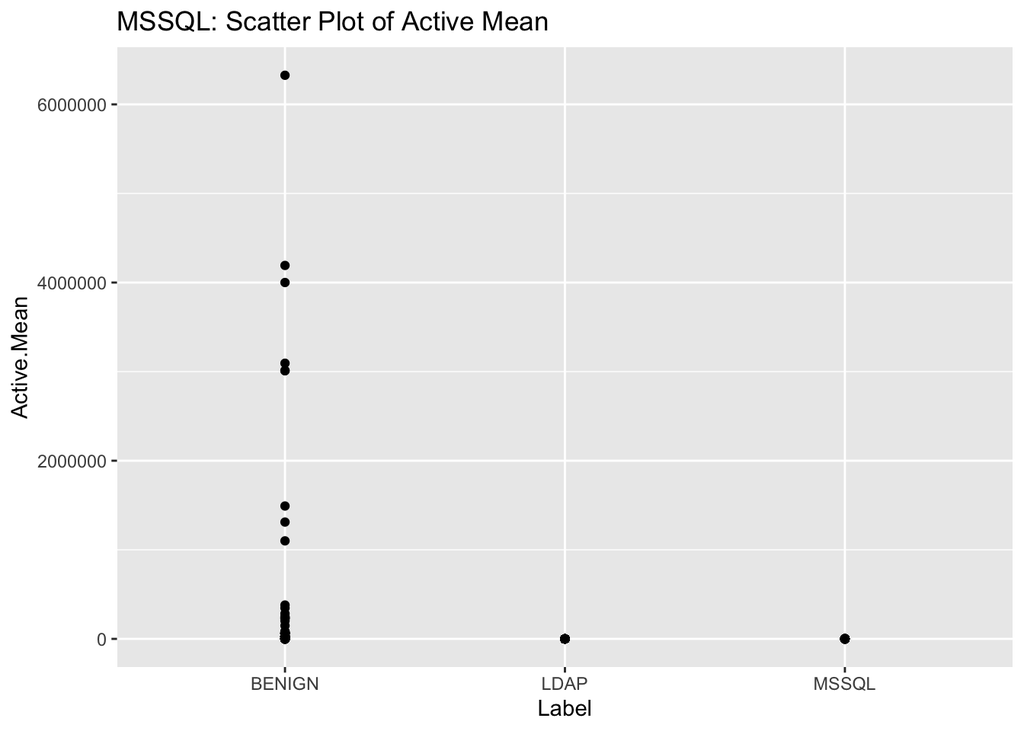

```r
ggplot(dfMSSQL,aes(x=Label, y=Active.Mean)) + geom_point()+ggtitle("MSSQL: Scatter Plot of Active Mean")
```

```r
MSSQL_grouped = dfMSSQL %>% group_by(Label) %>% select_if(is.numeric) %>% summarise_all(list(avg = mean, stdDev = sd)) %>% data.frame()

MSSQL_grouped
```

```
##    Label Total.Fwd.Packets_avg Total.Backward.Packets_avg Fwd.IAT.Total_avg
## 1 BENIGN              7.169257               7.2763385147       4003001.140
## 2   LDAP              2.015436               0.0140939597         47551.561
## 3  MSSQL              2.106609               0.0005041672          3482.599
##   Bwd.IAT.Total_avg Fwd.PSH.Flags_avg Bwd.Header.Length_avg Fwd.Packets.s_avg
## 1      3023190.1364     0.24006908463    -33037671.62003454          279916.2
## 2         3337.9698     0.00000000000            0.45100671         1602850.6
## 3          180.9202     0.00001274906            0.01460346         1586358.7
##   Bwd.Packets.s_avg Min.Packet.Length_avg Max.Packet.Length_avg
## 1    5887.822288243              8.350604              322.1244
## 2       0.006225565           1446.443624             1446.7745
## 3       0.048005629            559.484325              559.4994
##   Average.Packet.Size_avg Active.Mean_avg Idle.Mean_avg Inbound_avg
## 1                98.72242 56608.620898100   2454345.766   0.1675302
## 2              2169.38308     0.002013423     42304.194   0.9848993
```

[output cut: 21 more lines]